# Red wine exploration by Andre Marais

Andre Marais

January 15, 2016

### Univariate Plots Section

#### Data overview

Number of data points

```
## [1] 1599
```

Structure of data

```
## 'data.frame':    1599 obs. of  13 variables:
##  $ X                   : int  1 2 3 4 5 6 7 8 9 10 ...
##  $ fixed.acidity       : num  7.4 7.8 7.8 11.2 7.4 7.4 7.9 7.3 7.8 7.5 ...
##  $ volatile.acidity    : num  0.7 0.88 0.76 0.28 0.7 0.66 0.6 0.65 0.58 0.5 ...
##  $ citric.acid         : num  0 0 0.04 0.56 0 0 0.06 0 0.02 0.36 ...
##  $ residual.sugar      : num  1.9 2.6 2.3 1.9 1.9 1.8 1.6 1.2 2 6.1 ...
##  $ chlorides           : num  0.076 0.098 0.092 0.075 0.076 0.075 0.069 0.065 0.073 0.071 ...
##  $ free.sulfur.dioxide : num  11 25 15 17 11 13 15 15 9 17 ...
##  $ total.sulfur.dioxide: num  34 67 54 60 34 40 59 21 18 102 ...
##  $ density             : num  0.998 0.997 0.997 0.998 0.998 ...
##  $ pH                  : num  3.51 3.2 3.26 3.16 3.51 3.51 3.3 3.39 3.36 3.35 ...
##  $ sulphates           : num  0.56 0.68 0.65 0.58 0.56 0.56 0.46 0.47 0.57 0.8 ...
##  $ alcohol             : num  9.4 9.8 9.8 9.8 9.4 9.4 9.4 10 9.5 10.5 ...
##  $ quality             : int  5 5 5 6 5 5 5 7 7 5 ...
```

Looks like variable X might just be row numbers. It looks like quality might be rating factors instead of numeric values

Summary of data

```
##        X          fixed.acidity   volatile.acidity  citric.acid
##  Min.   :   1.0   Min.   : 4.60   Min.   :0.1200   Min.   :0.000
##  1st Qu.: 400.5   1st Qu.: 7.10   1st Qu.:0.3900   1st Qu.:0.090
##  Median : 800.0   Median : 7.90   Median :0.5200   Median :0.260
##  Mean   : 800.0   Mean   : 8.32   Mean   :0.5278   Mean   :0.271
##  3rd Qu.:1199.5   3rd Qu.: 9.20   3rd Qu.:0.6400   3rd Qu.:0.420
##  Max.   :1599.0   Max.   :15.90   Max.   :1.5800   Max.   :1.000
##  residual.sugar     chlorides       free.sulfur.dioxide
##  Min.   : 0.900   Min.   :0.01200   Min.   : 1.00
##  1st Qu.: 1.900   1st Qu.:0.07000   1st Qu.: 7.00
##  Median : 2.200   Median :0.07900   Median :14.00
##  Mean   : 2.539   Mean   :0.08747   Mean   :15.87
##  3rd Qu.: 2.600   3rd Qu.:0.09000   3rd Qu.:21.00
##  Max.   :15.500   Max.   :0.61100   Max.   :72.00
##  total.sulfur.dioxide    density             pH          sulphates
##  Min.   :  6.00       Min.   :0.9901   Min.   :2.740   Min.   :0.3300
##  1st Qu.: 22.00       1st Qu.:0.9956   1st Qu.:3.210   1st Qu.:0.5500
##  Median : 38.00       Median :0.9968   Median :3.310   Median :0.6200
##  Mean   : 46.47       Mean   :0.9967   Mean   :3.311   Mean   :0.6581
##  3rd Qu.: 62.00       3rd Qu.:0.9978   3rd Qu.:3.400   3rd Qu.:0.7300
##  Max.   :289.00       Max.   :1.0037   Max.   :4.010   Max.   :2.0000
##     alcohol         quality
##  Min.   : 8.40   Min.   :3.000
##  1st Qu.: 9.50   1st Qu.:5.000
##  Median :10.20   Median :6.000
##  Mean   :10.42   Mean   :5.636
##  3rd Qu.:11.10   3rd Qu.:6.000
##  Max.   :14.90   Max.   :8.000
```

Checking variables X and quality

```r
table(rw$quality)
```

```
##
##   3   4   5   6   7   8
##  10  53 681 638 199  18
```

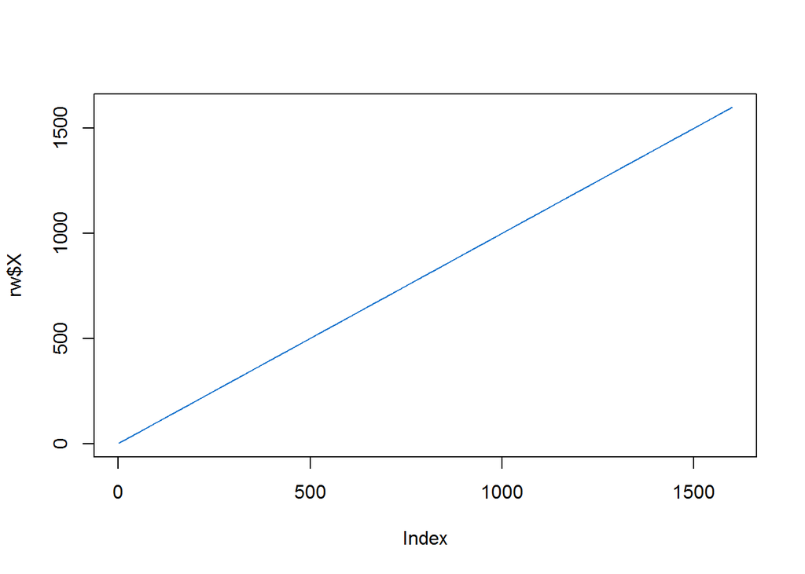

```r
plot(rw$X, type = 'l', col = 'dodgerblue3')
```

Initial observations

Variable X and be safely ignored and quality can be converted to factors. Most wines have a quality rating of 5, with 75% of the wines having a rating of 6 or lower. The mean alcohol percentage is 10.42% and the minimum pH is 2.74, which is *very* acidic.

### Basic Plots

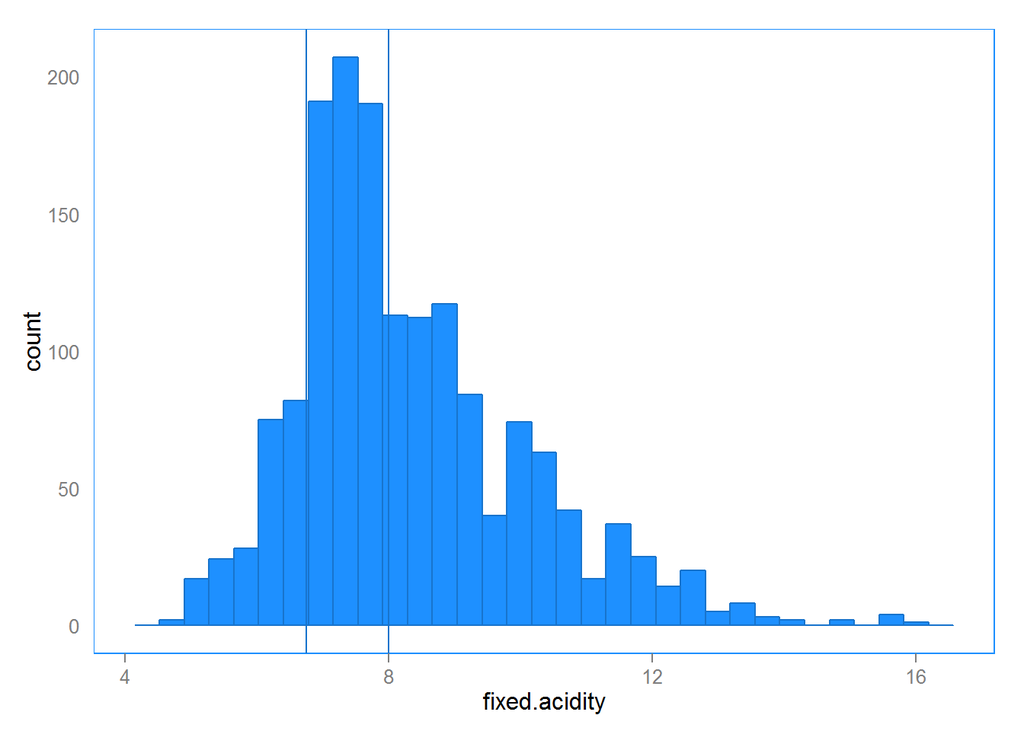

The fixed acidity peaks around 6.75 and 8.

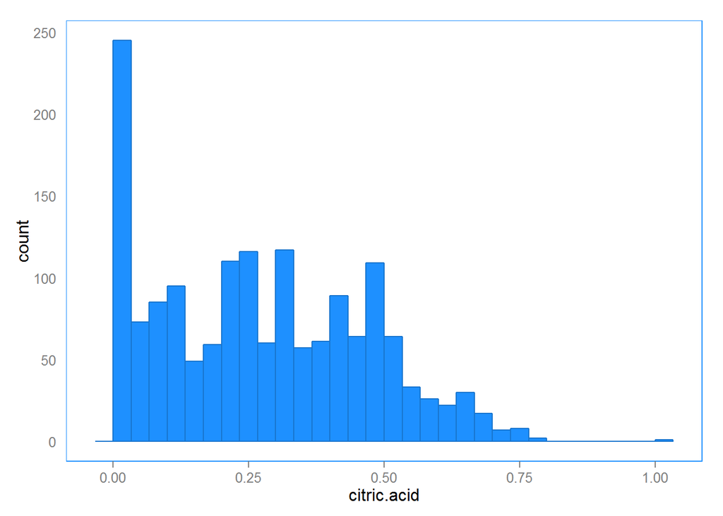

A relatively large portion (8%) of the wines have a citric acid level of 0.

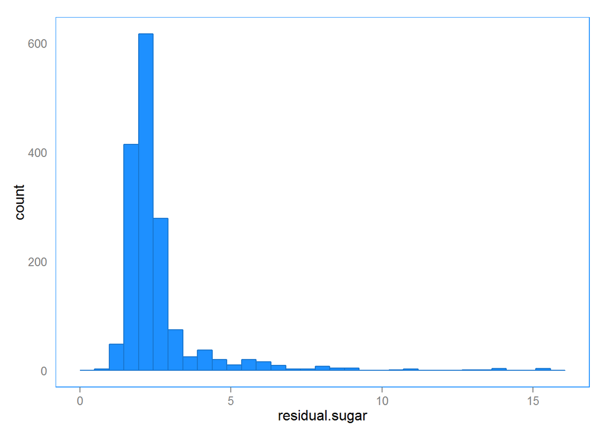

Excluding the 2.5% top quantile from the plot:

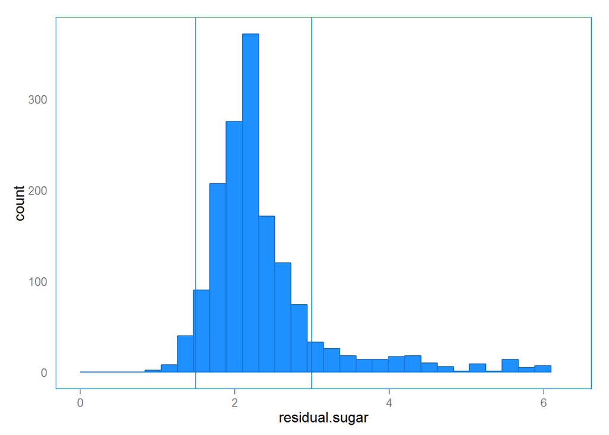

The residual sugar levels mostly sit around 1.5 and 3. The minimum residual sugar level is 0.9, so all red wines contain at least some sugar

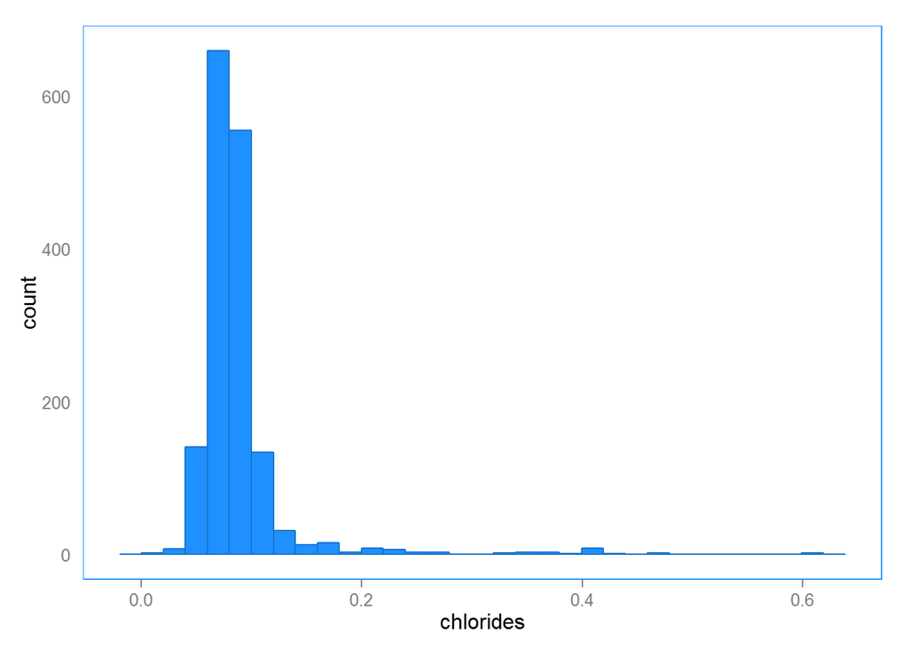

The chlorides data have a pretty long tail. Excluding the top 2.5% quantile again:

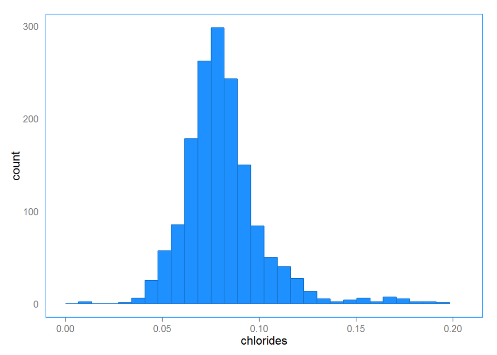

Barring the outliers, the chloride levels are quite symmetric around 0.081 (the mean for the data in the graph above)

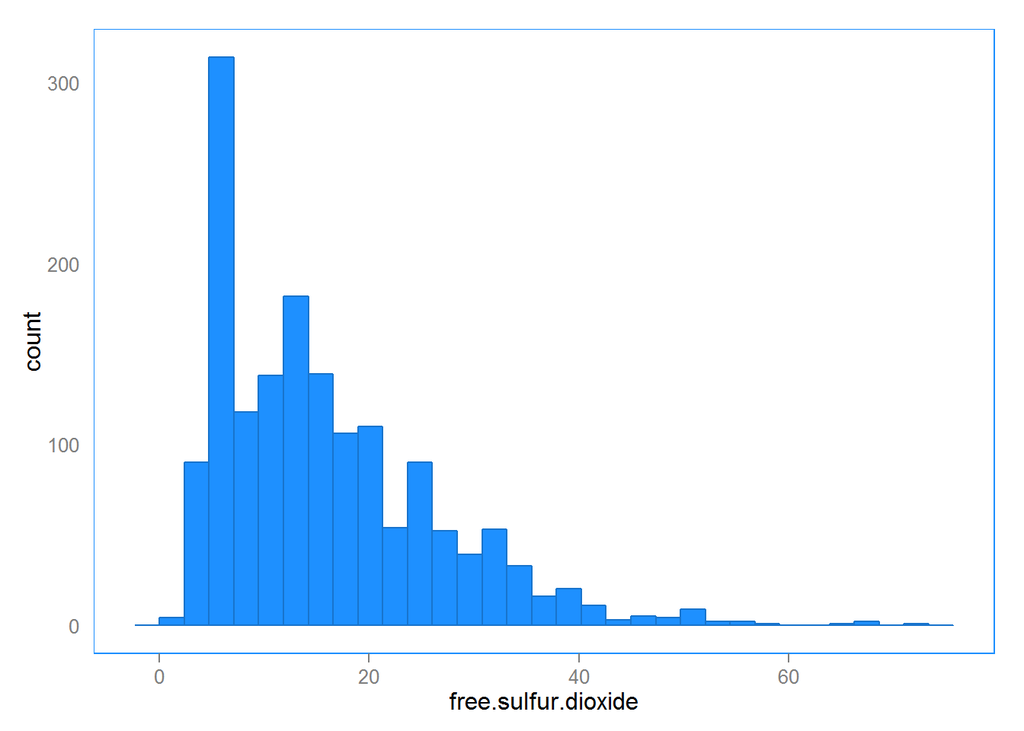

There is a peak of free sulfur dioxide levels between 5 and 6. Sulphur dioxide is in general a bad thing in wine (affects the taste and some people are allergic to it). The peak of sulfur dioxide levels might be due to compliance by most wineries with food laws.

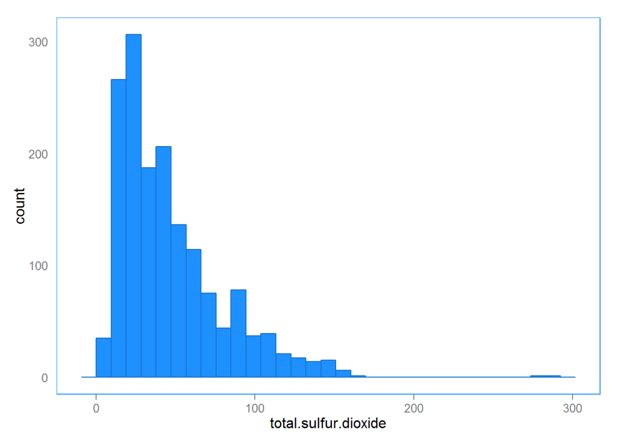

Total sulfur dioxide might not be that much more informative than the previous metric, since it’s dependent on the amount of wine in the bottle (the taste might be more related to the previous metric as opposed to total sulfur dioxide levels)

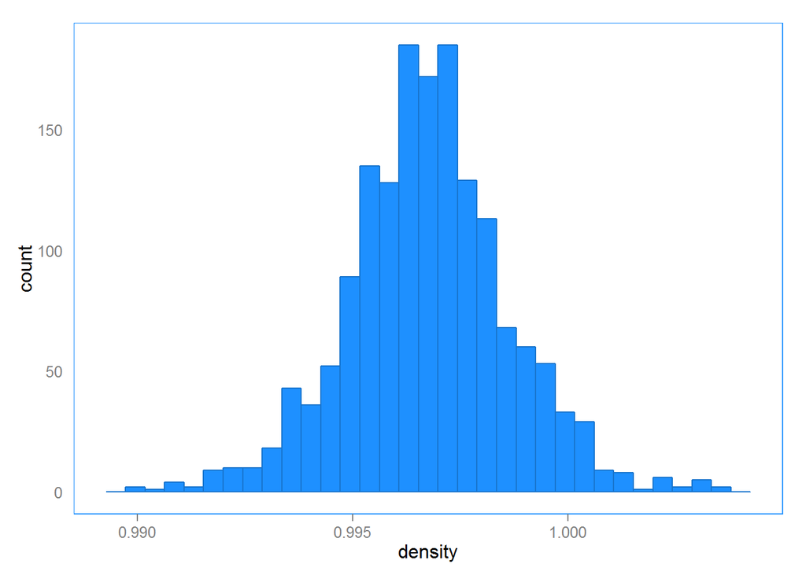

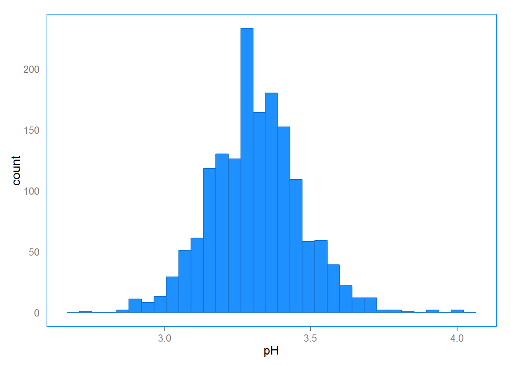

The density and pH histograms look like they might come from separate normal distributions. Surprisingly, the Shapiro test for normality show that they don’t. The p-value for the Shapiro test for both of these metrics are far less than 0.05. The null hypothesis for the Shapiro states that the values come from a normal distribution, while the alternative is that the values do *not* come from a normal distribution. With a p-value of less than 0.05 we can reject that null hypothesis in favor of the alternative. The p-value for density: 0.0000000194 and for pH: 0.0000017122

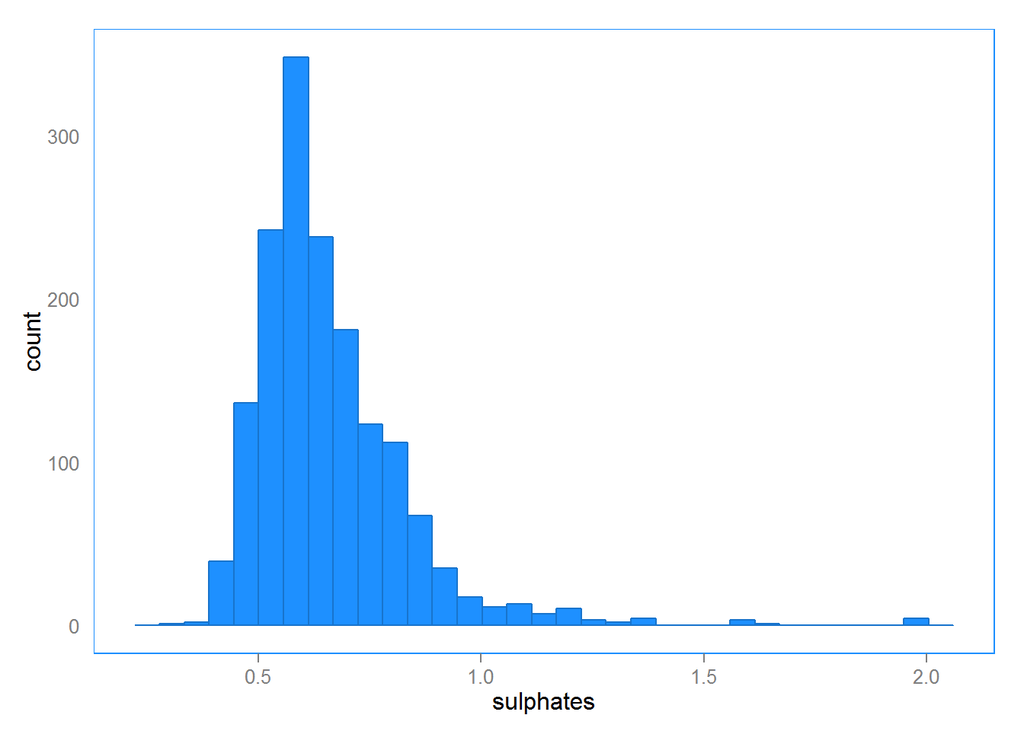

Sulphates also has a very long tail. Excluding the top 2.5% quantile again:

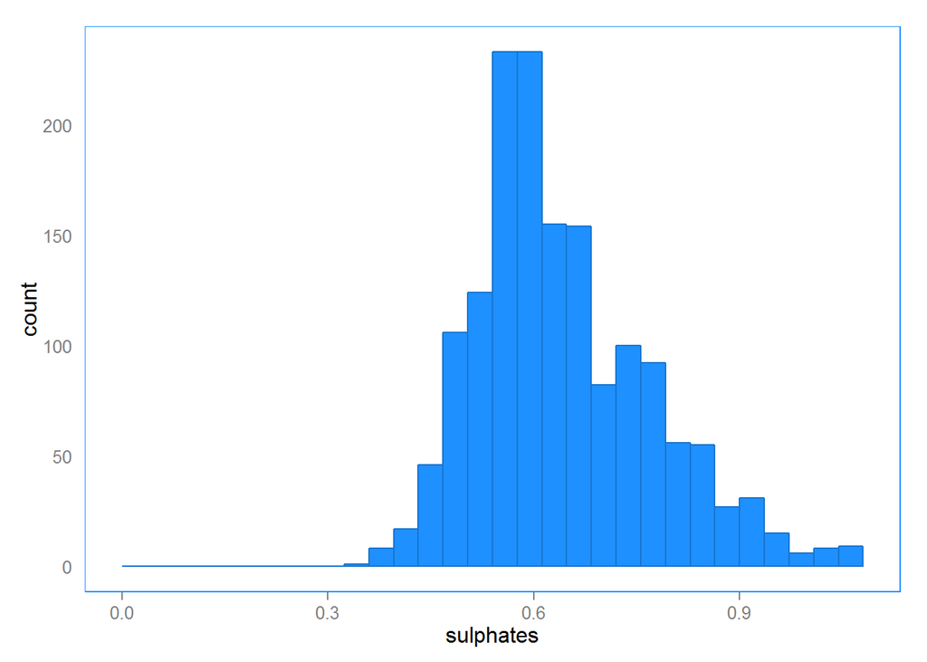

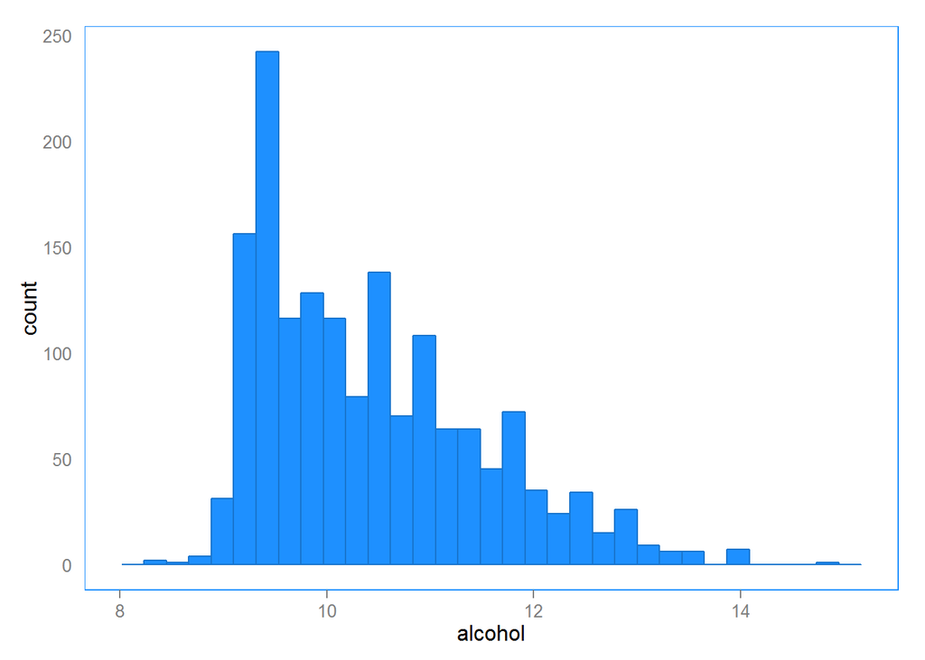

It looks like there is always at least *some* alcohol and sulphates in wine. The minimum quantity of alcohol found is 8.4 and for sulphates 0.33. It seems like sulphates is the go-to preservative for wine because of its antioxidant and antibacterial properties. Alcohol is a natural by-product of fermentation, so it shouldn’t be a surprise. The mode alcohol level is 9.5

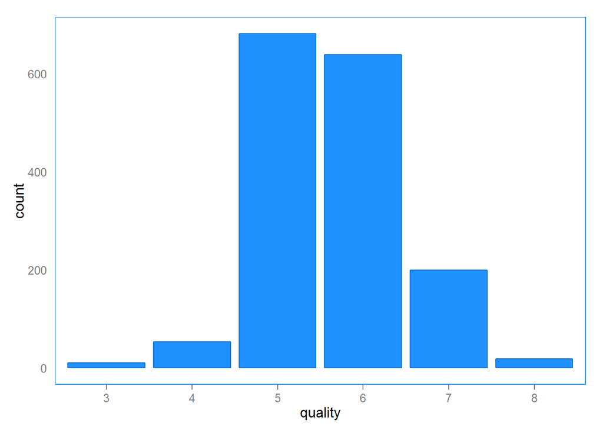

As stated previously, it might be more meaningful to treat the quality values as factors. Without knowing what the possible range is like for the ratings (ie does it go from 1 to 10, or only from 3 to 6), it’s difficult to say what these scores actually mean. I would assume a higher score is better. More than 96% of the wine has a rating of 5 or better.

### Univariate analysis

#### Data overview

The red wine data set has 1,599 data points, with 13 features (of which we can ignore one, namely X). All but one feature are numeric values - quality was converted to factors. Only a few features are easy to judge in terms of scale (ie is lower better?).  
A few things I found interesting were the peak values for some features, which *might* be due to legislation in some countries. Feature like free sulfur dioxide, pH and alcohol have definite peaks. While it’s not possible to determine whether it really is due to legislation or just coincidental, it will be interesting to see if it has an effect on the wine itself. The mode for sulphar, pH and acohol are 6, 3.3 and 9.5 respectively.  
I’m curious to see how the sulphate and alcohol levels affect the quality of the wine. Citric acid and sugar content might boil down to personal preference, but I’ll investigate the relation between those variables and the quality of the wine just the same.

### Bivariate Plots

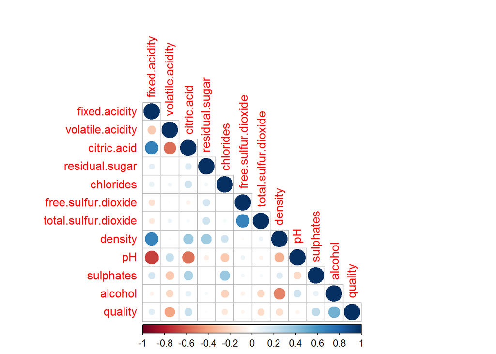

A larger more opaque circle indicates a more significant correlation. Blue indicates a positive correlation while red indicates a negative correlation. From the graph above we can see it’s worthwhile to look at the link between quality and alcohol, volatile acidity and sulphates levels. Other variables we can look at include density vs alcohol and density vs fixed acidity. It’s interesting to see there isn’t a strong correlation between the sulphur features and quality, which is strange. Will investigate this further.

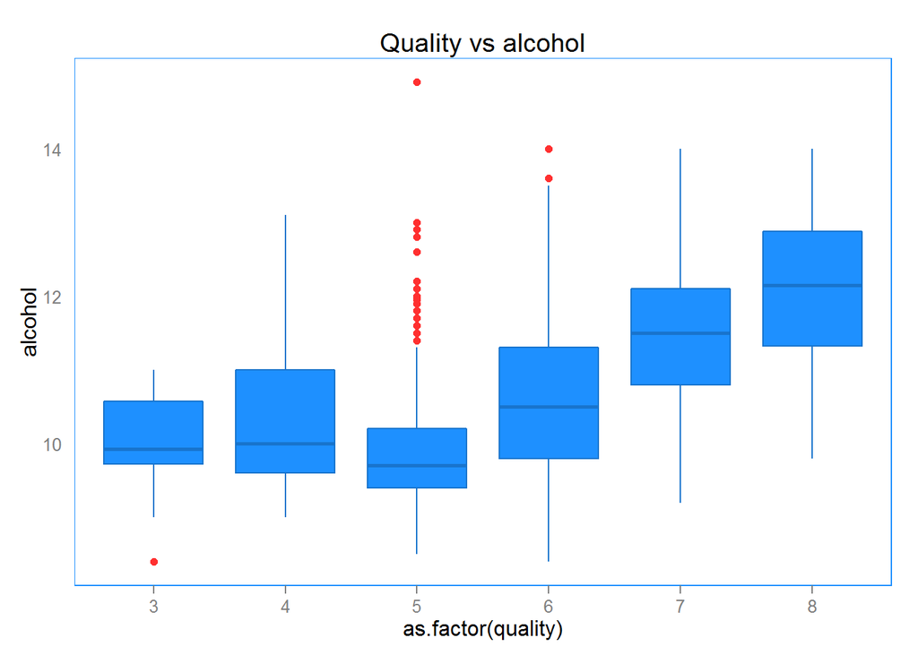

Note the amount of outliers (red dots) for wine which has a quality rating of 5.

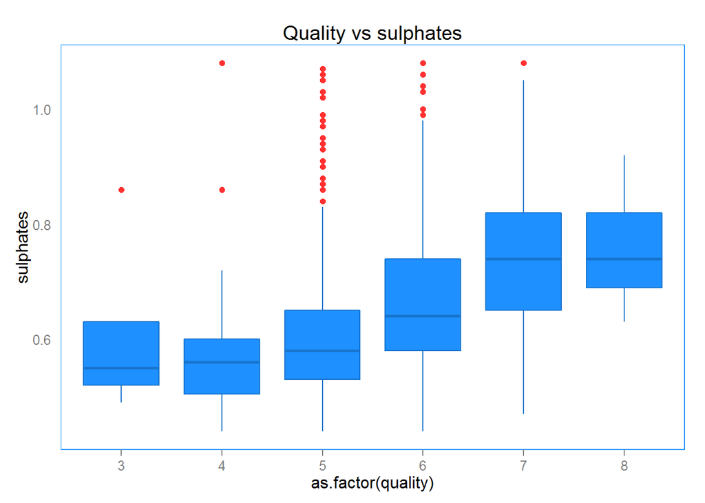

Once again a lot of outliers with wine which has a quality rating of 5.

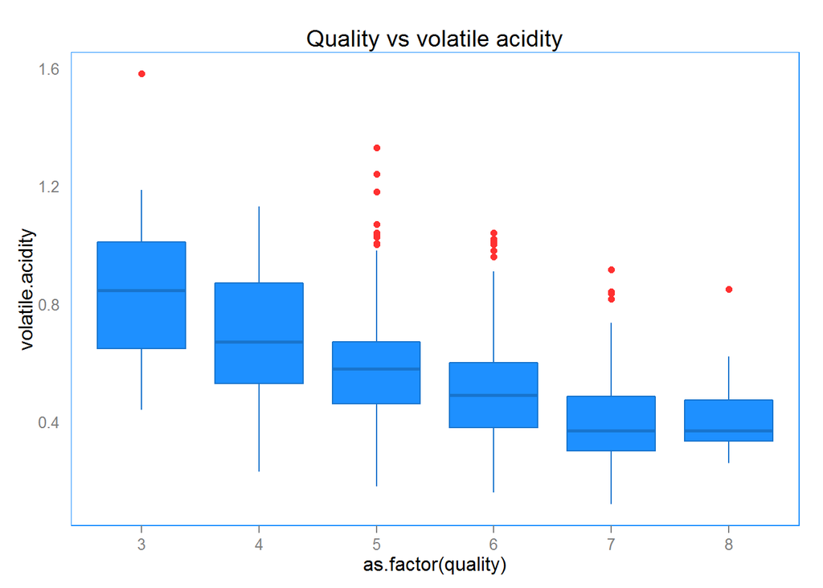

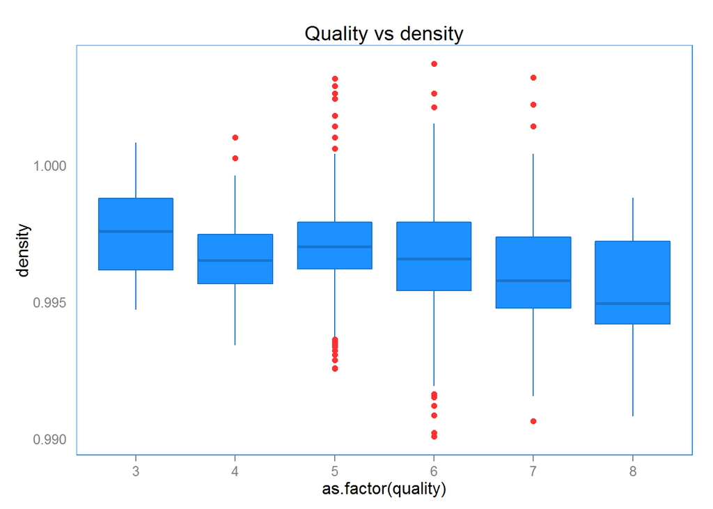

Looks like there might be a link between quality and density

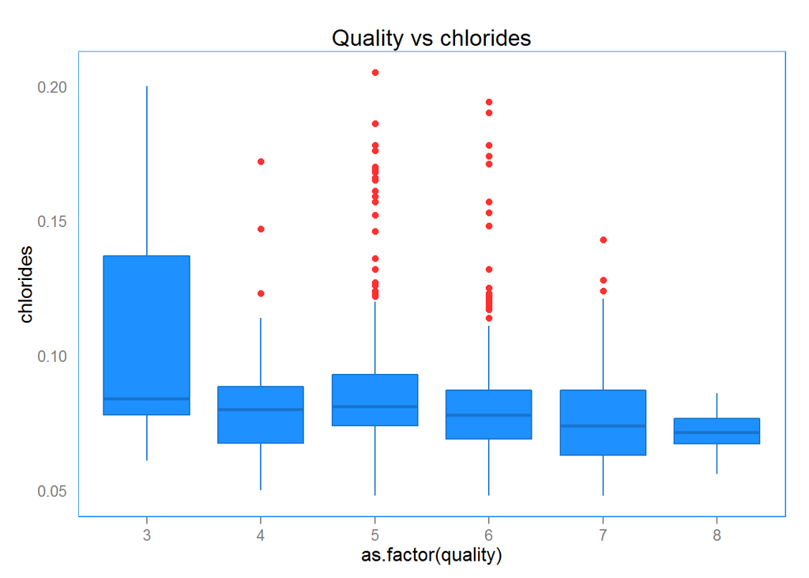

Doesn’t look promising.

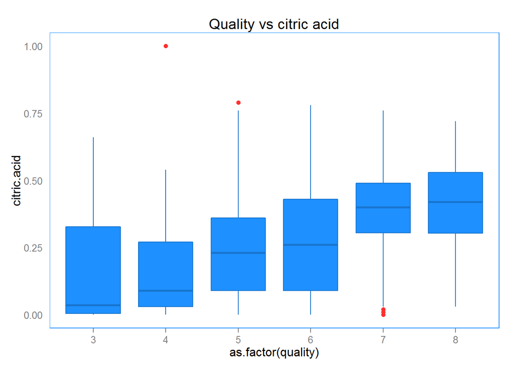

Looks like there is a good link between quality and citric acid levels.

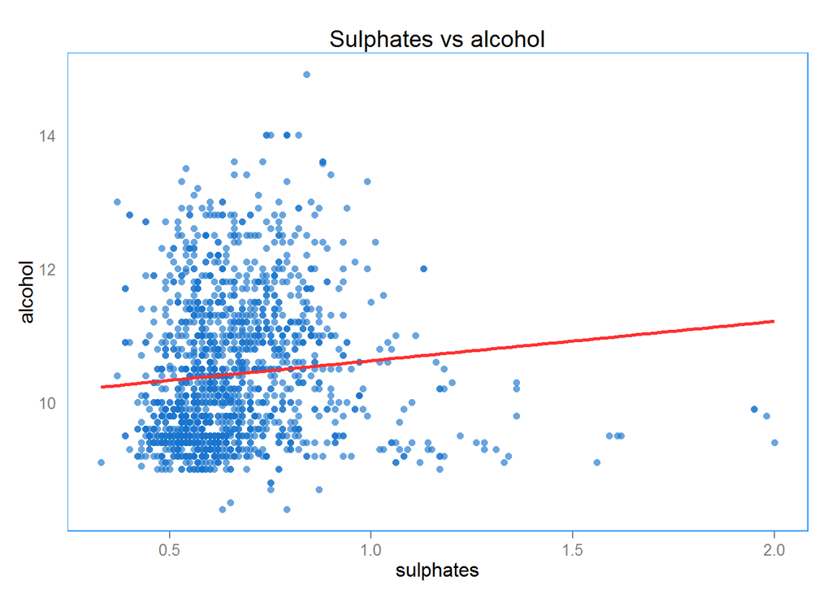

The red line is a fitted linear model. Such a low correlation level 0.0935948 means the features aren’t redundant. For modelling purposes it means we can use both features.

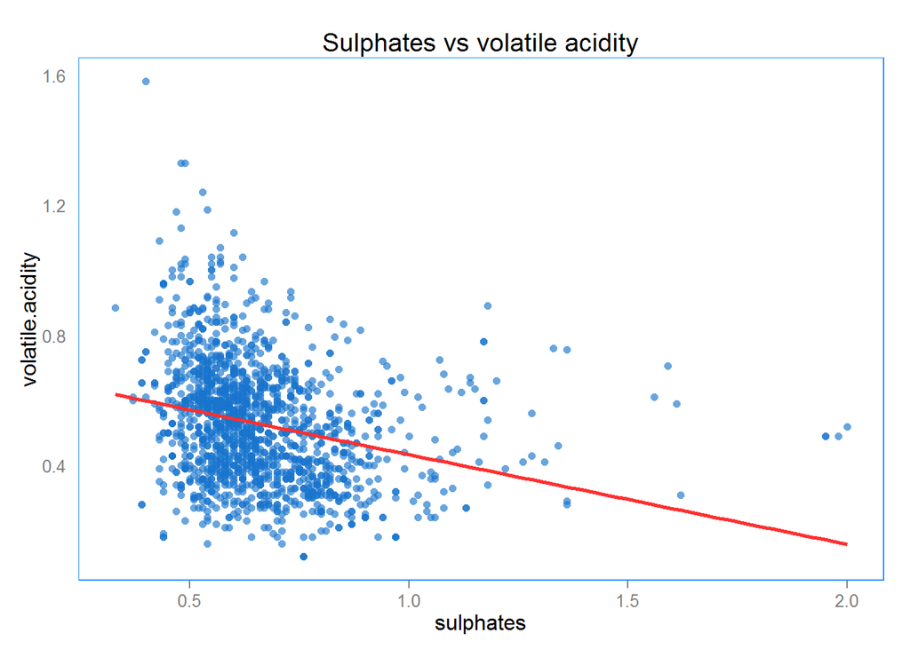

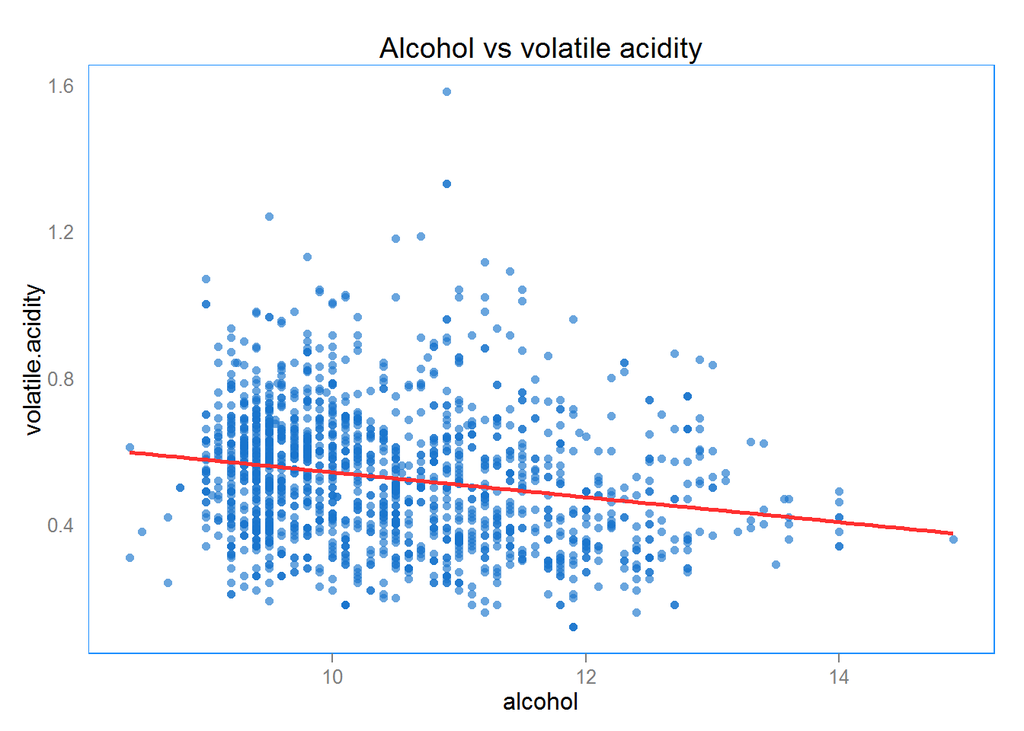

A weak correlation -0.202288, might be valuable the model.

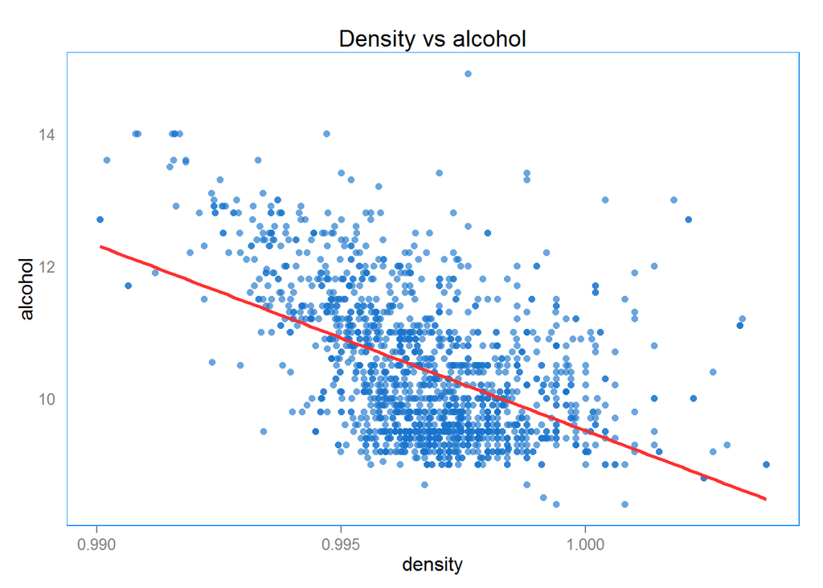

A stronger negative correlation -0.4961798, will have to see if this adds value to the model.

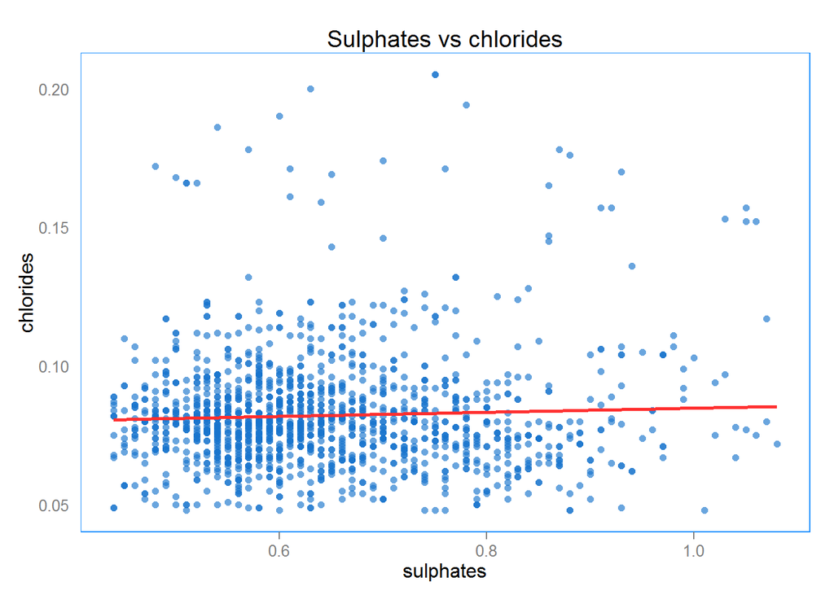

A stronger correlation 0.3712605, but not high enough to consider ignoring this feature.

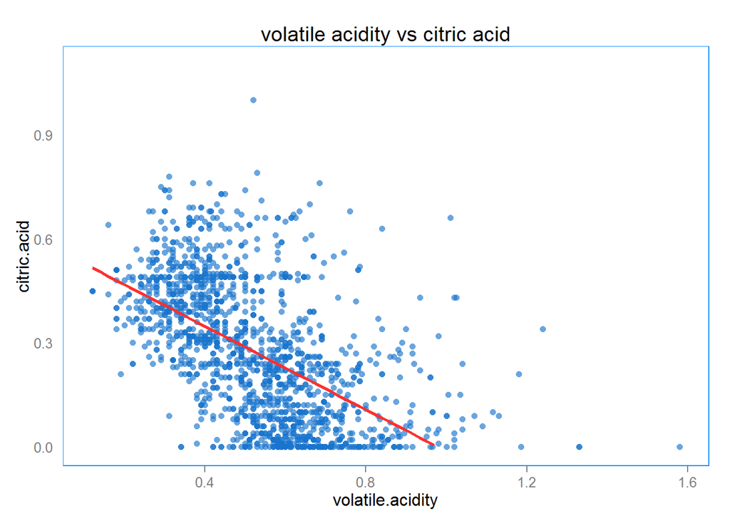

A relatively strong negative correlation -0.5524957, will have to see if this is worthwhile.

### Bivariate analysis

The quality of the wine increases along with higher alcohol content and lower volatile acidity levels. There are quite a few alcohol outliers with wines having a quality rating of 5. *If* 5 is the average rating for wine, it wouldn’t be too naive to assume that a rating of 5 is the go-to rating for wines where the judge can’t place it with confidence. This might be the reason why there is a higher variance with the wine with a rating of 5.  
I want to see if I can build a model which can predict the quality of a wine, based on the given features. The features which seem most useful for now include alcohol, sulphates and volatile acidity. Density, chloride and citric acid might also be useful, but they are quite correlated with alcohol, sulphates and volatile acidity respectively.